# AFSC RACE Groundfish and Shellfish Survey Public Data

## This code is primarily maintained by:

**Emily Markowitz** (Emily.Markowitz AT noaa.gov; [@EmilyMarkowitz-NOAA](https://github.com/EmilyMarkowitz-NOAA))  
Research Fisheries Biologist  
*Bering Sea Groundfish Survey Team*

Alaska Fisheries Science Center,  
National Marine Fisheries Service,  
National Oceanic and Atmospheric Administration,  
Seattle, WA 98195

[figure not shown]

> The code in this repository is regularly being updated and improved. Please refer to releases for finalized products and project milestones. *The FOSS dataset is only updated once a year and may be slightly behind the GitHub repository.* This metadata is regarding scripts and data last ran and pushed to the AFSC oracle on **April 10, 2023**.

# Cite this data

Use the below bibtext [citation](https://github.com/afsc-gap-products/gap_public_data//blob/main/CITATION.bib), as cited in our group’s [citation repository](https://github.com/afsc-gap-products/citations/blob/main/cite/bibliography.bib) for citing the data from this data portal (NOAA Fisheries Alaska Fisheries Science Center, 2023). Add “note = {Accessed: mm/dd/yyyy}” to append the day this data was accessed.

```
## @misc{FOSSAFSCData,
##    author = {{NOAA Fisheries Alaska Fisheries Science Center}},
##    year = {2023},
##    title = {Fisheries One Stop Shop Public Data: RACE Division Bottom Trawl Survey Data Query},
##    howpublished = {https://www.fisheries.noaa.gov/foss},
##    publisher = {{U.S. Dep. Commer.}},
##    copyright = {Public Domain}
## }
```

# Collabrators and data users

Below are a few packages and products currently using this data. If you have developed a product, performed an analysis, or exhibited this data in any way, reach out so we can showcase your hard work.

Description

Contacts

[figure not shown]

[NOAA Fisheries Distribution Mapping and Analysis Portal](https://apps-st.fisheries.noaa.gov/dismap)

[NOAA Fisheries Office of Science and Technology](https://www.fisheries.noaa.gov/contact/office-science-and-technology)

[figure not shown]

[Pull data with python](https://pyafscgap.org/) and explore the [in-browser visualization tool](https://app.pyafscgap.org/). Reference their [example Python notebook](https://mybinder.org/v2/gh/SchmidtDSE/afscgap/main?urlpath=/tree/index.ipynb)

[The Eric and Wendy Schmidt Center for Data Science and the Environment at UC Berkeley](https://dse.berkeley.edu/); Sam Pottinger, Ciera Martinez, Giulia Zarpellon, and Kevin Koy

# Metadata

## Data description (short)

This dataset includes zero-filled (presence and absence) observations and catch-per-unit-effort (CPUE) estimates for all identified species at for index stations by the Resource Assessment and Conservation Engineering Division (RACE) Groundfish Assessment Program (GAP) of the Alaska Fisheries Science Center (AFSC). There are no legal restrictions on access to the data. The data from this dataset are shared on the Fisheries One Stop Stop (FOSS) platform (https://www.fisheries.noaa.gov/foss/). The GitHub repository for the scripts that created this code can be found at https://github.com/afsc-gap-products/gap_public_data. For more information about codes used in the tables, please refer to the survey code books (https://www.fisheries.noaa.gov/resource/document/groundfish-survey-species-code-manual-and-data-codes-manual). These data were last updated April 10, 2023.

## Data description (long)

The Resource Assessment and Conservation Engineering Division (RACE) Groundfish Assessment Program (GAP) of the Alaska Fisheries Science Center (AFSC) conducts fisheries-independent bottom trawl surveys to monitor the condition of the demersal fish and crab stocks of Alaska. These data are developed to describe the temporal distribution and abundance of commercially and ecologically important groundfish species, examine the changes in the species composition of the fauna over time and space, and describe the physical environment of the groundfish habitat.

There are no legal restrictions on access to the data. They reside in the public domain and can be freely distributed. Users must read and fully comprehend the metadata prior to use. Data should not be used beyond the limits of the source scale. Acknowledgement of NOAA, as the source from which these data were obtained, in any publications and/or other representations of these data, is suggested. These data are compiled and approved annually after each summer survey season. The data from previous years are unlikely to change substantially once published.

These data are zero-filled (presence and absence) observations from surveys conducted on fishing vessels. These surveys monitor trends in distribution and abundance of groundfish, crab, and bottom-dwelling species in Alaska’s marine ecosystems. These data include estimates of catch-per-unit-effort (CPUE) for all identified species for index stations. Some survey data are excluded, such as non-standard stations, surveys completed in earlier years using different/non-standard gear, and special tows and non-standard data collections.

Though not included in the public data, these surveys also collect oceanographic and environmental data, and biological data such as length, weight, stomach contents (to learn more about diet), otoliths (fish ear bones to learn about age), and tissue samples for genetic analysis, all of which can be shared upon special request. Also not included in the public data are estimated biomass (average total weight of all fish and crabs sampled) of crabs and groundfish that support the creation of annual stock assessments.

## Bottom trawl surveys and regions

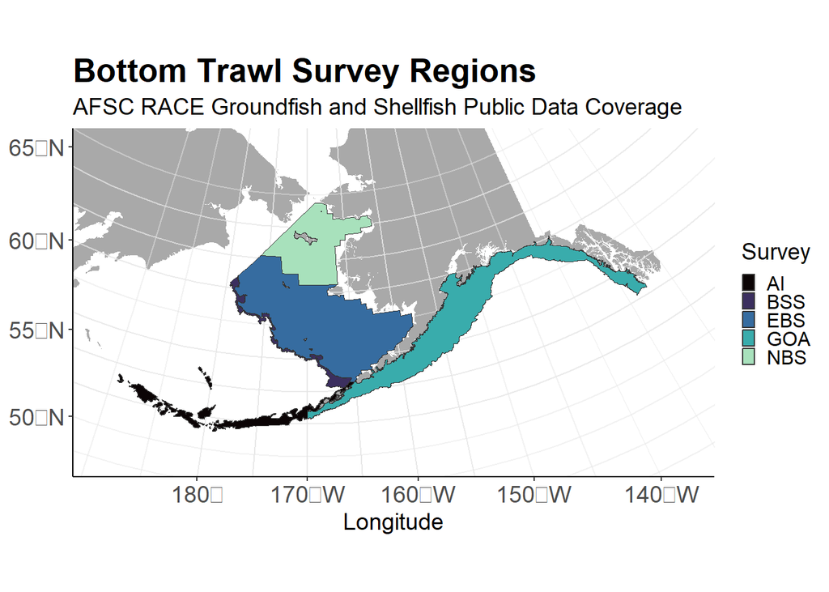

- **Aleutian Islands (AI)** (Von Szalay and Raring, 2020)
  - Triennial (1990s)/Biennial since 2000 in even years
  - Modified Index-Stratified Random of Successful Stations Survey Design
- **Eastern Bering Sea Slope (BSS)** (Hoff, 2016)
  - Intermittent (funding dependent)
  - Modified Index-Stratified Random of Successful Stations Survey Design
- **Eastern Bering Sea Shelf (EBS)** (Markowitz et al., 2022)
  - Annual
  - Fixed stations at center of 20 x 20 nm grid
- **Gulf of Alaska (GOA)** (Von Szalay and Raring, 2018)
  - Triennial (1990s)/Biennial since 2001 in odd years
  - Stratified Random Survey Design
- **Northern Bering Sea (NBS)** (Markowitz et al., 2022)
  - Biennial/Annual
  - Fixed stations at center of 20 x 20 nm grid

## Relevant technical memorandums

Hoff, G. R. (2016). *Results of the 2016 eastern Bering Sea upper continental slope survey of groundfishes and invertebrate resources* (NOAA Tech. Memo. NOAA-AFSC-339). U.S. Dep. Commer. https://doi.org/10.7289/V5/TM-AFSC-339

Markowitz, E. H., Dawson, E. J., Charriere, N. E., Prohaska, B. K., Rohan, S. K., Stevenson, D. E., and Britt, L. L. (2022). *Results of the 2021 eastern and northern Bering Sea continental shelf bottom trawl survey of groundfish and invertebrate fauna* (NOAA Tech. Memo. NMFS-F/SPO-452; p. 227). U.S. Dep. Commer. https://doi.org/10.25923/g1ny-y360

NOAA Fisheries Alaska Fisheries Science Center. (2023). *Fisheries one stop shop public data: RACE division bottom trawl survey data query*. https://www.fisheries.noaa.gov/foss; U.S. Dep. Commer.

Resource Assessment, A. F. S. C. (U.S.)., and Division, C. E. (2021). *Groundfish survey data codes and forms*. https://doi.org/https://doi.org/10.25923/kp5e-1g02

Von Szalay, P. G., and Raring, N. W. (2018). *Data report: 2017 Gulf of Alaska bottom trawl survey* (NOAA Tech. Memo. NMFS-AFSC-374). U.S. Dep. Commer. https://doi.org/http://doi.org/10.7289/V5/TM-AFSC-374

Von Szalay, P. G., and Raring, N. W. (2020). *Data report: 2018 Aleutian Islands bottom trawl survey* (NOAA Tech. Memo. NMFS-AFSC-409). U.S. Dep. Commer. https://doi.org/https://doi.org/10.25923/qe5v-fz70

## User resources

- [AFSC RACE Groundfish Assessment Program (GAP)](https://www.fisheries.noaa.gov/contact/groundfish-assessment-program).
- [AFSC Resource Assessment and Conservation Engineering Division (RACE)](https://www.fisheries.noaa.gov/about/resource-assessment-and-conservation-engineering-division).
- For more information about codes used in the tables, please refer to the [survey code books](https://www.fisheries.noaa.gov/resource/document/groundfish-survey-species-code-manual-and-data-codes-manual) (Resource Assessment and Division, 2021).
- Find [past reports](https://www.fisheries.noaa.gov/resource/publication-database/noaa-institutional-repository) about these surveys.
- [GitHub repository](https://github.com/afsc-gap-products/gap_public_data/).
- Learn more about other [research surveys conducted at AFSC](https://www.fisheries.noaa.gov/alaska/ecosystems/alaska-fish-research-surveys).

## Access constraints

**There are no legal restrictions on access to the data. They reside in the public domain and can be freely distributed.**

**User Constraints:** Users must read and fully comprehend the metadata prior to use. Data should not be used beyond the limits of the source scale. Acknowledgement of AFSC Groundfish Assessment Program, as the source from which these data were obtained, in any publications and/or other representations of these data, is suggested.

**Address:** Alaska Fisheries Science Center (AFSC) National Oceanic and Atmospheric Administration (NOAA)  
Resource Assessment and Conservation Engineering Division (RACE)  
Groundfish Assessment Program (GAP) 7600 Sand Point Way, N.E. bldg. 4  
Seattle, WA 98115 USA

**General questions and more specific data requests** can be sent to afsc.gap.metadata@noaa.gov or submitted as an [issue on our GitHub Organization](https://github.com/afsc-gap-products/data-requests). The version of this data used for stock assessments can be found through the Alaska Fisheries Information Network (AKFIN). For questions about the eastern Bering Sea surveys, contact Duane Stevenson (Duane.Stevenson@noaa.gov). For questions about the Gulf of Alaska or Aleutian Islands surveys, contact Ned Laman (Ned.Laman@noaa.gov). For questions specifically about crab data in any region, contact Mike Litzow (Mike.Litzow@noaa.gov), the Shellfish Assessment Program lead.

For questions, comments, and concerns specifically about the [Fisheries One Stop Shop (FOSS)](https://www.fisheries.noaa.gov/foss) platform, please contact us using the Comments page on the [FOSS](https://www.fisheries.noaa.gov/foss) webpage.

## Column-level metadata

| Column name | Column name (long) | Units | Description |
| --- | --- | --- | --- |
| year | Year | year | Year the survey was conducted in. |
| srvy | Survey | text abbreviated | Abbreviated survey names. The column ‘srvy’ is associated with the ‘survey’ and ‘survey_id’ columns. Northern Bering Sea (NBS), Southeastern Bering Sea (EBS), Bering Sea Slope (BSS), Gulf of Alaska (G… |
| survey | Survey Name | text | Name and description of survey. The column ‘survey’ is associated with the ‘srvy’ and ‘survey_id’ columns. |
| survey_definition_id | Survey ID | ID code | This number uniquely identifies a survey. Name and description of survey. The column ‘survey_id’ is associated with the ‘srvy’ and ‘survey’ columns. For a complete list of surveys, review the [code bo… |
| cruise | Cruise ID | ID code | This is a six-digit number identifying the cruise number of the form: YYYY99 (where YYYY = year of the cruise; 99 = 2-digit number and is sequential; 01 denotes the first cruise that vessel made in th… |
| haul | Haul Number | ID code | This number uniquely identifies a sampling event (haul) within a cruise. It is a sequential number, in chronological order of occurrence. |
| hauljoin | Haul ID | ID code | This is a unique numeric identifier assigned to each (vessel, cruise, and haul) combination. |
| stratum | Stratum ID | ID code | RACE database statistical area for analyzing data. Strata were designed using bathymetry and other geographic and habitat-related elements. The strata are unique to each survey series. Stratum of valu… |
| station | Station ID | ID code | Alpha-numeric designation for the station established in the design of a survey. |
| vessel_name | Vessel Name | text | Name of the vessel used to collect data for that haul. The column ‘vessel_name’ is associated with the ‘vessel_id’ column. Note that it is possible for a vessel to have a new name but the same vessel … |
| vessel_id | Vessel ID | ID code | ID number of the vessel used to collect data for that haul. The column ‘vessel_id’ is associated with the ‘vessel_name’ column. Note that it is possible for a vessel to have a new name but the same ve… |
| vessel_id | Vessel ID | ID code | ID number of the vessel used to collect data for that haul. The column ‘vessel_id’ is associated with the ‘vessel_name’ column. Note that it is possible for a vessel to have a new name but the same ve… |
| date_time | Date and Time of Haul | MM/DD/YYYY HH::MM | The date (MM/DD/YYYY) and time (HH:MM) of the beginning of the haul. |
| latitude_dd_start | Start Latitude (decimal degrees) | decimal degrees | Latitude (one hundred thousandth of a decimal degree) of the start of the haul. |
| longitude_dd_start | Start Longitude (decimal degrees) | decimal degrees | Longitude (one hundred thousandth of a decimal degree) of the start of the haul. |
| latitude_dd_end | End Latitude (decimal degrees) | decimal degrees | Latitude (one hundred thousandth of a decimal degree) of the end of the haul. |
| longitude_dd_end | End Longitude (decimal degrees) | decimal degrees | Longitude (one hundred thousandth of a decimal degree) of the end of the haul. |
| species_code | Taxon Code | ID code | The species code of the organism associated with the ‘common_name’ and ‘scientific_name’ columns. For a complete species list, review the [code books](https://www.fisheries.noaa.gov/resource/document/… |
| itis | ITIS Taxonomic Serial Number | ID code | Species code as identified in the Integrated Taxonomic Information System (https://itis.gov/). |
| worms | World Register of Marine Species Taxonomic Serial Number | ID code | Species code as identified in the World Register of Marine Species (WoRMS) (https://www.marinespecies.org/). |
| common_name | Taxon Common Name | text | The common name of the marine organism associated with the ‘scientific_name’ and ‘species_code’ columns. For a complete species list, review the [code books](https://www.fisheries.noaa.gov/resource/do… |
| scientific_name | Taxon Scientific Name | text | The scientific name of the organism associated with the ‘common_name’ and ‘species_code’ columns. For a complete taxon list, review the [code books](https://www.fisheries.noaa.gov/resource/document/gr… |
| taxon_confidence | Taxon Confidence Rating | category | Confidence in the ability of the survey team to correctly identify the taxon to the specified level, based solely on identification skill (e.g., not likelihood of a taxon being caught at that station … |
| cpue_kgha | Weight CPUE (kg/ha) | kilograms per hectare | Catch weight (kilograms) divided by area (hectares) swept by the net. |
| cpue_kgkm2 | Weight CPUE (kg/km<sup>2</sup>) | kilograms per kilometers squared | Catch weight (kilograms) divided by area (squared kilometers) swept by the net. |
| cpue_noha | Number CPUE (no/ha) | count per hectare | Catch number (in number of organisms) per area (hectares) swept by the net. |
| cpue_nokm2 | Number CPUE (no/km<sup>2</sup>) | count per kilometers squared | Catch number (in number of organisms) per area (squared kilometers) swept by the net. |
| weight_kg | Taxon Weight (kg) | kilograms | Weight (thousandths of a kilogram) of individuals in a haul by taxon. |
| count | Taxon Count | count, whole number resolution | Total number of individuals caught in haul by taxon, represented in whole numbers. |
| bottom_temperature_c | Bottom Temperature (Degrees Celsius) | degrees Celsius | Bottom temperature (tenths of a degree Celsius); NA indicates removed or missing values. |
| bottom_temperature_c | Bottom Temperature (Degrees Celsius) | degrees Celsius | Bottom temperature (tenths of a degree Celsius); NA indicates removed or missing values. |
| surface_temperature_c | Surface Temperature (Degrees Celsius) | degrees Celsius | Surface temperature (tenths of a degree Celsius); NA indicates removed or missing values. |
| depth_m | Depth (m) | degrees Celsius | Bottom depth (tenths of a meter). |
| distance_fished_km | Distance Fished (km) | degrees Celsius | Distance the net fished (thousandths of kilometers). |
| net_width_m | Net Width (m) | meters | Measured or estimated distance (meters) between wingtips of the trawl. |
| net_height_m | Net Height (m) | meters | Measured or estimated distance (meters) between footrope and headrope of the trawl. |
| area_swept_ha | Area Swept (ha) | hectares | The area the net covered while the net was fishing (hectares), defined as the distance fished times the net width. |
| duration_hr | Tow Duration (decimal hr) | hours, tenths resolution | This is the elapsed time between start and end of a haul (decimal hours). |
| performance | Haul Performance Code | category | This denotes what, if any, issues arose during the haul. For more information, review the [code books](https://www.fisheries.noaa.gov/resource/document/groundfish-survey-species-code-manual-and-data-c… |

# Access the data

While pulling data, please keep in mind that this is a very large file. For reference:

```
## RACEBASE_FOSS.FOSS_CPUE_ZEROFILLED:
##   rows: 36342299
##   cols: 37
##   10.064 GB
```

## Access data interactively through the FOSS platform

Select, filter, and package this and other NOAA Fisheries data from the [Fisheries One Stop Shop (FOSS)](https://www.fisheries.noaa.gov/foss) platform. This user-friendly portal is maintained through `Oracle APEX`. A useful intro to using APIs in `R` can be found [here](https://www.dataquest.io/blog/r-api-tutorial/). A user guide for the FOSS platform can be found [here](https://www.fisheries.noaa.gov/foss/f?p=215:7:7542600605674:::::).

[figure not shown]

FOSS data platform

### Connect to the API with R

More information about how to amend API links can be found [here](https://docs.oracle.com/en/database/oracle/oracle-rest-data-services/22.3/books.html#AELIG90103/).

Load the first 25 rows of data

```r
# install.packages(c("httr", "jsonlite"))
library("httr")
library("jsonlite")
# link to the API
api_link <- "https://apps-st.fisheries.noaa.gov/ods/foss/afsc_groundfish_survey/"
```

```r
res <- httr::GET(url = api_link)
# res # Test connection
data <- jsonlite::fromJSON(base::rawToChar(res$content))
# names(data)
knitr::kable(head(data$items, 3))
```

| year | srvy | survey | survey_id | cruise | haul | stratum | station | vessel_name | vessel_id | date_time | latitude_dd | longitude_dd | species_code | common_name | scientific_name | taxon_confidence | cpue_kgha | cpue_kgkm2 | cpue_kg1000km2 | cpue_noha | cpue_nokm2 | cpue_no1000km2 | weight_kg | count | bottom_temperature_c | surface_temperature_c | depth_m | distance_fished_km | net_width_m | … |
| --- | --- | --- | --- | --- | --- | --- | --- | --- | --- | --- | --- | --- | --- | --- | --- | --- | --- | --- | --- | --- | --- | --- | --- | --- | --- | --- | --- | --- | --- | --- |
| 2002 | AI | Aleutian Islands Bottom Trawl Survey | 5.2E+001 | 2.00201E+005 | 6.0E+000 | 7.22E+002 | 307-63 | Vesteraalen | 9.4E+001 | 05/17/2002 18:56:58 | 5.3737209999999997E+001 | -1.6701570000000001E+002 | 9.502E+004 | feathery bryozoan | Eucratea loricata | Low | 1.7493999999999999E-002 | 1.7494449999999999E+000 | 1.7494451079999999E+003 | NA | NA | NA | 4.3999999999999997E-002 | 0 | 4.0999999999999996E+000 | 5.2999999999999998E+000 | 1.87E+002 | 1.5609999999999999E+000 | 1.6111999999999998E+001 | … |
| 2002 | AI | Aleutian Islands Bottom Trawl Survey | 5.2E+001 | 2.00201E+005 | 6.0E+000 | 7.22E+002 | 307-63 | Vesteraalen | 9.4E+001 | 05/17/2002 18:56:58 | 5.3737209999999997E+001 | -1.6701570000000001E+002 | 7.9E+004 | squid unid. | Decapodiformes | High | 2.2266000000000001E-002 | 2.2265670000000002E+000 | 2.2265665009999998E+003 | 3.180809E+000 | 3.1808092900000003E+002 | 3.1808092869500001E+005 | 5.6000000000000001E-002 | 8.0E+000 | 4.0999999999999996E+000 | 5.2999999999999998E+000 | 1.87E+002 | 1.5609999999999999E+000 | 1.6111999999999998E+001 | … |
| 2002 | AI | Aleutian Islands Bottom Trawl Survey | 5.2E+001 | 2.00201E+005 | 6.0E+000 | 7.22E+002 | 307-63 | Vesteraalen | 9.4E+001 | 05/17/2002 18:56:58 | 5.3737209999999997E+001 | -1.6701570000000001E+002 | 2.4191E+004 | shortfin eelpout | Lycodes brevipes | High | 3.5784000000000003E-002 | 3.5784099999999999E+000 | 3.5784104480000001E+003 | 7.9520199999999996E-001 | 7.9520231999999993E+001 | 7.9520232174000004E+004 | 8.9999999999999997E-002 | 2.0E+000 | 4.0999999999999996E+000 | 5.2999999999999998E+000 | 1.87E+002 | 1.5609999999999999E+000 | 1.6111999999999998E+001 | … |

Load the first 10000 rows of data

```r
res <- httr::GET(url = paste0(api_link, "?offset=0&limit=10000"))
data <- jsonlite::fromJSON(base::rawToChar(res$content))
dim(data$items)
```

```
## [1] 10000    36
```

Filter by Species name: Show all the data where the product name contains pollock Please note that here the word pollock is case sensitive.

The notation for finding a string is to use % around it. Since % is a reserved character in a URL, you have to replace `%` with `%25`.

```r
res <- httr::GET(url = paste0(api_link, '?q={"common_name":{"$like":"%25pollock%25"}}'))
data <- jsonlite::fromJSON(base::rawToChar(res$content))
knitr::kable(head(data$items, 3))
```

| year | srvy | survey | survey_id | cruise | haul | stratum | station | vessel_name | vessel_id | date_time | latitude_dd | longitude_dd | species_code | common_name | scientific_name | taxon_confidence | cpue_kgha | cpue_kgkm2 | cpue_kg1000km2 | cpue_noha | cpue_nokm2 | cpue_no1000km2 | weight_kg | count | bottom_temperature_c | surface_temperature_c | depth_m | distance_fished_km | net_width_m | … |
| --- | --- | --- | --- | --- | --- | --- | --- | --- | --- | --- | --- | --- | --- | --- | --- | --- | --- | --- | --- | --- | --- | --- | --- | --- | --- | --- | --- | --- | --- | --- |
| 2002 | AI | Aleutian Islands Bottom Trawl Survey | 5.2E+001 | 2.00201E+005 | 5.0E+000 | 7.21E+002 | 306-64 | Vesteraalen | 9.4E+001 | 05/17/2002 16:39:57 | 5.3768709999999999E+001 | -1.6707259999999999E+002 | 2.174E+004 | walleye pollock | Gadus chalcogrammus | High | 6.3990000000000002E-003 | 6.3989099999999999E-001 | 6.3989137200000005E+002 | 3.9993200000000001E-001 | 3.9993211000000002E+001 | 3.9993210752999999E+004 | 1.6E-002 | 1.0E+000 | 4.4000000000000004E+000 | 5.0999999999999996E+000 | 6.5E+001 | 1.6759999999999999E+000 | 1.4919E+001 | … |
| 2002 | AI | Aleutian Islands Bottom Trawl Survey | 5.2E+001 | 2.00201E+005 | 6.0E+000 | 7.22E+002 | 307-63 | Vesteraalen | 9.4E+001 | 05/17/2002 18:56:58 | 5.3737209999999997E+001 | -1.6701570000000001E+002 | 2.174E+004 | walleye pollock | Gadus chalcogrammus | High | 7.7532230000000002E+000 | 7.7532226400000002E+002 | 7.7532226369299996E+005 | 1.1530434E+001 | 1.153043367E+003 | 1.1530433665179999E+006 | 1.95E+001 | 2.9E+001 | 4.0999999999999996E+000 | 5.2999999999999998E+000 | 1.87E+002 | 1.5609999999999999E+000 | 1.6111999999999998E+001 | … |
| 2002 | AI | Aleutian Islands Bottom Trawl Survey | 5.2E+001 | 2.00201E+005 | 2.0E+000 | 7.22E+002 | 303-64 | Vesteraalen | 9.4E+001 | 05/17/2002 10:20:08 | 5.3790370000000003E+001 | -1.6725810000000001E+002 | 2.174E+004 | walleye pollock | Gadus chalcogrammus | High | 1.06858064E+002 | 1.0685806397E+004 | 1.0685806397293E+007 | 1.2519113900000001E+002 | 1.2519113928999999E+004 | 1.251911392852E+007 | 2.5180000000000001E+002 | 2.95E+002 | 4.0999999999999996E+000 | 5.0E+000 | 1.64E+002 | 1.488E+000 | 1.5836E+001 | … |

### Subset data

Here, as an example, we can subset the data for the 2018 Aleutian Islands Bottom Trawl Survey.

```r
res <- httr::GET(url = api_link, query = list(year = "2018", srvy = "AI"))
data <- jsonlite::fromJSON(base::rawToChar(res$content))
x <- data$items
x <- x[,c("srvy", "year", "stratum", "station", "vessel_name", "latitude_dd", "longitude_dd",
          "species_code", "common_name", "scientific_name", "taxon_confidence",
          "cpue_kgha", "cpue_noha", "weight_kg", "count",
          "bottom_temperature_c", "surface_temperature_c", "depth_m")]
knitr::kable(head(x, 3))
```

[output not shown]

## Access data via Oracle

If the user has access to the AFSC `Oracle` database, the user can use `SQL developer` to view and pull the FOSS public data directly from the `RACEBASE_FOSS` `Oracle` schema.

### Connect to Oracle from R

Many users will want to access the data from `Oracle` using `R`. The user will need to install the `RODBC` `R` package and ask OFIS (IT) connect `R` to `Oracle`. Then, use the following code in `R` to establish a connection from `R` to `Oracle`:

Here, the user can write in their username and password directly into the `RODBC` connect function. Never save usernames or passwords in scripts that may be intentionally or unintentionally shared with others. If no username and password is entered in the function, pop-ups will appear on the screen asking for the username and password.

```r
#' Define RODBC connection to ORACLE
#'
#' @param schema default = 'AFSC'.
#'
#' @return oracle channel connection
#' @export
#'
#' @examples
#' # Not run
#' # channel <- oracle_connect()
oracle_connect <- function(
    schema='AFSC',
    username = NULL,
    passowrd = NULL){(echo=FALSE)

  library("RODBC")
  library("getPass")
  if (is.null(username)) {
    username <- getPass(msg = "Enter your ORACLE Username: ")
  }
  if (is.null(password)) {
    password <- getPass(msg = "Enter your ORACLE Password: ")
  }
  channel  <- RODBC::odbcConnect(
    paste(schema),
    paste(username),
    paste(password),
    believeNRows=FALSE)
  return(channel)
}

channel <- oracle_connect()
```

### Select all data

Once connected, pull and save (if needed) the table into the `R` environment.

```r
# Pull table from oracle into R environment
a <- RODBC::sqlQuery(channel, "SELECT * FROM RACEBASE_FOSS.FOSS_CPUE_ZEROFILLED")
# Save table to local directory
write.csv(x = a, file = "RACEBASE_FOSS-FOSS_CPUE_ZEROFILLED.csv")
```

### Subset data

```r
# Pull data
a <- RODBC::sqlQuery(channel, "SELECT * FROM RACEBASE_FOSS.FOSS_CPUE_ZEROFILLED
WHERE SRVY = 'EBS'
AND COMMON_NAME = 'Pacific cod'
AND YEAR >= 2010
AND YEAR < 2021")
# Save table to local directory
write.csv(x = a, file = "RACEBASE_FOSS-FOSS_CPUE_ZEROFILLED-ebs_pcod_2010-2020.csv")
```

### Join catch and haul data

If this file is too large, you can join catch and haul data. Pull the `RACEBASE_FOSS.JOIN_FOSS_CPUE_CATCH` and `RACEBASE_FOSS.JOIN_FOSS_CPUE_HAUL` tables, which are much smaller, and combine the table locally yourself.

These datasets, JOIN_FOSS_CPUE_CATCH and JOIN_FOSS_CPUE_HAUL, when full joined by the HAULJOIN variable, includes zero-filled (presence and absence) observations and catch-per-unit-effort (CPUE) estimates for all identified species at for index stations by the Resource Assessment and Conservation Engineering Division (RACE) Groundfish Assessment Program (GAP) of the Alaska Fisheries Science Center (AFSC). There are no legal restrictions on access to the data. The data from this dataset are shared on the Fisheries One Stop Stop (FOSS) platform (https://www.fisheries.noaa.gov/foss/). The GitHub repository for the scripts that created this code can be found at https://github.com/afsc-gap-products/gap_public_data. For more information about codes used in the tables, please refer to the survey code books (https://www.fisheries.noaa.gov/resource/document/groundfish-survey-species-code-manual-and-data-codes-manual). These data were last updated April 10, 2023.

```
## RACEBASE_FOSS.JOIN_FOSS_CPUE_CATCH:
##   rows: 36342299
##   cols: 13
##   2.785 GB
```

```
## RACEBASE_FOSS.JOIN_FOSS_CPUE_HAUL:
##   rows: 31608
##   cols: 25
##   0.007 GB
```

To join these tables in Oracle, you may use a variant of the following code:

```sql
SELECT * FROM RACEBASE_FOSS.JOIN_FOSS_CPUE_HAUL
FULL JOIN RACEBASE_FOSS.JOIN_FOSS_CPUE_CATCH
ON RACEBASE_FOSS.JOIN_FOSS_CPUE_HAUL.HAULJOIN = RACEBASE_FOSS.JOIN_FOSS_CPUE_CATCH.HAULJOIN;
```

# Suggestions and comments

If the data or metadata can be improved, please create a pull request, [submit an issue to the GitHub organization](https://github.com/afsc-gap-products/data-requests/issues), [submit an issue to the code’s repository](https://github.com/afsc-gap-products/gap_public_data//issues), reach out the the survey team leads (listed above), or to [Fisheries One Stop Shop (FOSS)](https://www.fisheries.noaa.gov/foss) platform managers.

## NOAA README

This repository is a scientific product and is not official communication of the National Oceanic and Atmospheric Administration, or the United States Department of Commerce. All NOAA GitHub project code is provided on an ‘as is’ basis and the user assumes responsibility for its use. Any claims against the Department of Commerce or Department of Commerce bureaus stemming from the use of this GitHub project will be governed by all applicable Federal law. Any reference to specific commercial products, processes, or services by service mark, trademark, manufacturer, or otherwise, does not constitute or imply their endorsement, recommendation or favoring by the Department of Commerce. The Department of Commerce seal and logo, or the seal and logo of a DOC bureau, shall not be used in any manner to imply endorsement of any commercial product or activity by DOC or the United States Government.

## NOAA License

Software code created by U.S. Government employees is not subject to copyright in the United States (17 U.S.C. §105). The United States/Department of Commerce reserve all rights to seek and obtain copyright protection in countries other than the United States for Software authored in its entirety by the Department of Commerce. To this end, the Department of Commerce hereby grants to Recipient a royalty-free, nonexclusive license to use, copy, and create derivative works of the Software outside of the United States.

[U.S. Department of Commerce](https://www.commerce.gov/) | [National Oceanographic and Atmospheric Administration](https://www.noaa.gov) | [NOAA Fisheries](https://www.fisheries.noaa.gov/)